# Actuarial Valuation Report

## 1 Abstract

### 1.1 Overview

### 1.2 Data

The data used for the Report has been provided by the Company and I take no responsibility for its accuracy as I have not undertaken extensive background checks.

### 1.3 Assumptions of Valuation

The Assumptions used in the report are selected by the company.

The Actuarial Assumptions used in the report may be changed from one period to another depending on changing expectations, experience, changes in regulations or other factors.

This Report should not be the sole basis for any decision taken about the benefit plan.

Due consideration must be given to alternatives and expected future movements in the market or any force that could cause the reality to be significantly different from assumptions made.

### 1.4 Signatory Actuary

## 2 Benefit Plan and Actuarial Methodology

### 2.1 Benefit Plan

Below are the details of the Plan Valued

Particulars

Details

Type of Plan

Defined Benefit

Employer’s Contribution

100%

Employee Contibution

Salary for calculation of Gratuity

Salary upon leaving service (Any Reason)

Normal Retirement Age

62 years

Vesting Period

5 years

Benefit on normal Retirement

Based on the Gratuity Act 1972, Indian Parliament (latest amendment)

Benefit on leaving service earlier than Retirement (Not Death)

Same as normal retirement, but the benefit is computed on the basis of date of leaving service

Benefit on death during service

Same as normal retirement with no vesting period applicable

Limit

2e+06

Gratuity Formula

15/26 * Last drawn salary * Number of years of Past service

### 2.2 Actuarial Methodology

#### Project Unit Credit Method

## 3 Valuation Assumptions

### 3.1 Financial Assumptions

| Particulars | For period ending on 2017-03-31 | For period ending on 2018-03-31 |
| --- | --- | --- |
| Interest Rate | 0.075 | 0.07 |
| Salary Increase | 0.070 | 0.05 |
| Expected Return on Assets | 0.060 | 0.03 |

### 3.2 Demographic Assumptions

The Company was advised that the assumptions have to be set according to the Paragraph 73 to 91 of the Accountancy Standards 15 (Revised 2015).

### Attritiona and Retirement Age

| Particulars | For period ending on 2017-12-31 | For period ending on 2018-03-31 |
| --- | --- | --- |
| Retirement Age | 62 | 62 |
| Attrition Rate | 21 % | 20 % |

### Assumed Mortality Rates: *Indian Assured Lives Mortality 2016*

No Adjustment were made on the Life Table data

| Age(x) | Mortality(qx) |
| --- | --- |
| 14 | 0.000549 |
| 15 | 0.000614 |
| 16 | 0.000680 |
| 17 | 0.000743 |
| 18 | 0.000800 |
| 19 | 0.000848 |
| 20 | 0.000888 |
| 21 | 0.000919 |
| 22 | 0.000943 |
| 23 | 0.000961 |
| 24 | 0.000974 |
| 25 | 0.000984 |
| 26 | 0.000994 |
| 27 | 0.001004 |
| 28 | 0.001017 |
| 29 | 0.001034 |
| 30 | 0.001056 |
| 31 | 0.001084 |
| 32 | 0.001119 |
| 33 | 0.001164 |
| 34 | 0.001218 |
| 35 | 0.001282 |
| 36 | 0.001358 |
| 37 | 0.001447 |
| 38 | 0.001549 |
| 39 | 0.001667 |
| 40 | 0.001803 |
| 41 | 0.001959 |
| 42 | 0.002140 |
| 43 | 0.002350 |

[output cut: 64 more lines]

## 4 Employee Statitics

### 4.1 Summary Statitics

| Particulars | For period ending on 2017-12-31 | For period ending on 2018-03-31 |
| --- | --- | --- |
| Total Number of Employees | 660.0 | 641.0 |
| Years of Service Valued | 700.0 | 656.0 |
| Average Past Service | 1.1 | 1.0 |
| Mean Salary | 7500.0 | 7477.5 |
| Mean Age | 33.0 | 33.8 |
| Mean Service Years left | 28.0 | 28.2 |
| Total Monthly Salary | 4800000.0 | 4793075.0 |

### 4.2 Age Analysis

| The_Decade_of_Life | No_of_Employees |
| --- | --- |
| 2 | 285 |
| 3 | 208 |
| 4 | 82 |
| 5 | 40 |
| 6 | 26 |

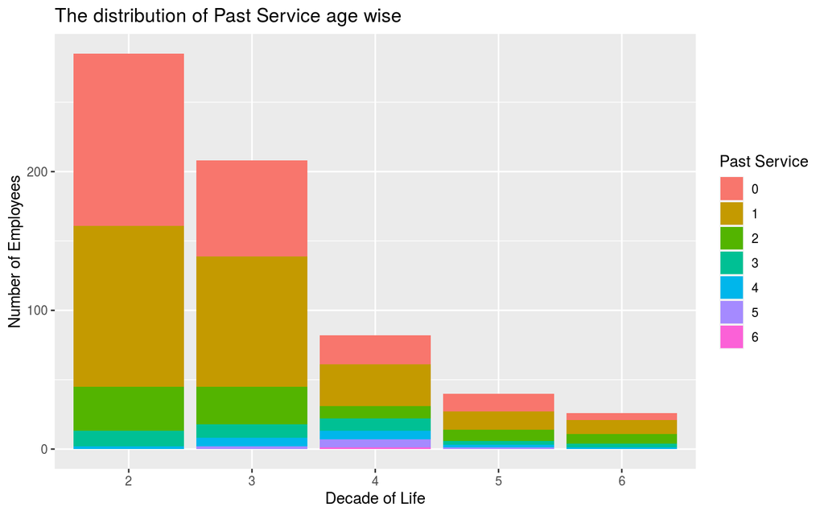

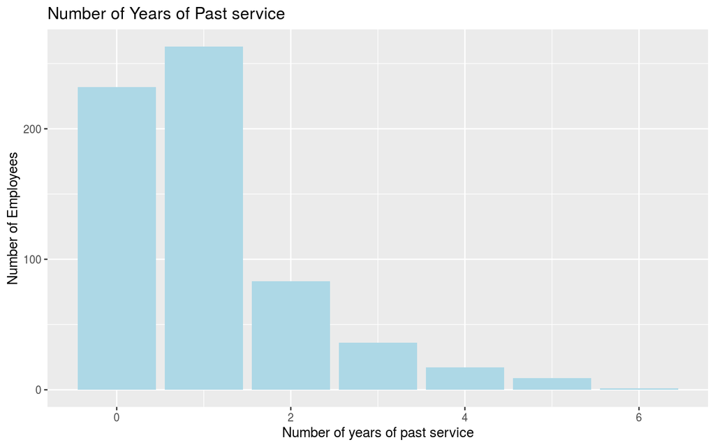

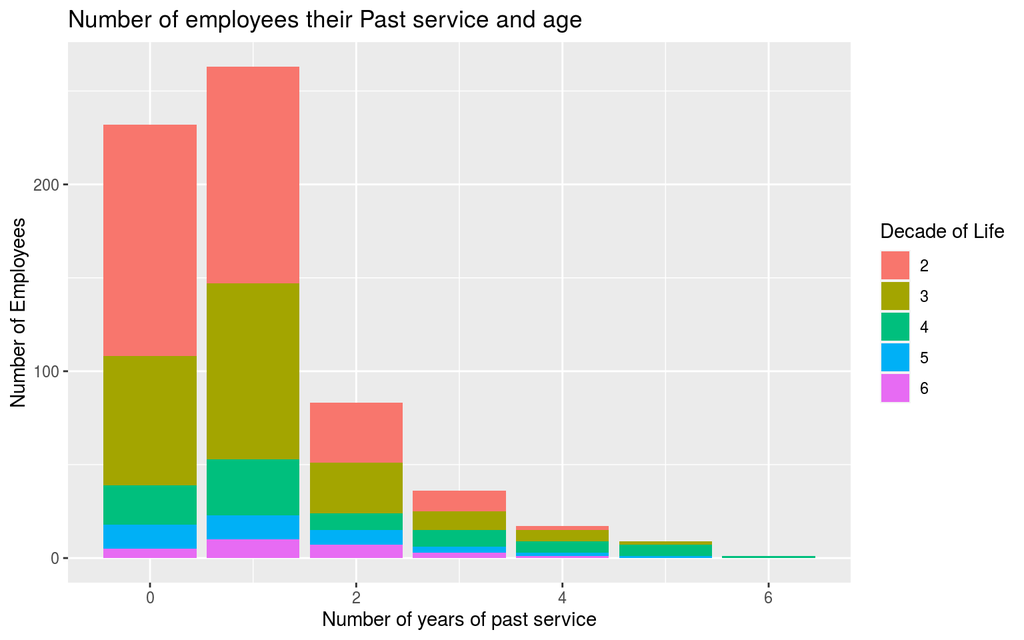

## 5 Valuation Results

### 5.1 Changes is Present Value of Obligation

| Particulars | For period ending on 2017-03-31 | For period ending on 2018-03-31 |
| --- | --- | --- |
| Present Value of Obligation in the Beginning | 3000000 | 3200000.0 |
| Acquisition Adjustments | 0 | 0.0 |
| Interest Cost | 300000 | 199109.2 |
| Past Service Cost | 0 | 0.0 |
| Current Service Costs | 0 | 538512.6 |
| Settlement Costs | 0 | 0.0 |
| Benefits Paid | -200000 | -250000.0 |
| Actuarial Gain/Loss on Obligation | 100000 | -351685.3 |
| Present Value of Obligation at the end | 3200000 | 3335936.4 |

### 5.2 Changes is Fair Value of Plan Assets

| Particulars | 2017-03-31 | 2018-03-31 |
| --- | --- | --- |
| Fair Value of Plan Assets in the Beginning | 1000 | 346900.000 |
| Acquisition Adjustments | 0 | 0.000 |
| Expected Return on Plan Assets | 500 | 11514.185 |
| Employer’s Contribution | 300 | 30000.000 |
| Employee’s Contribution | 0 | 0.000 |
| Benefits Paid | -250 | -25000.000 |
| Actuarial Gain/Loss on Obligation | 15 | -5551.185 |
| Fair Value of Plan Assets at the end | 346900 | 357863.000 |

### 5.3 Value of Plan Assets

| Particulars | For period ending on 2017-03-31 | For period ending on 2018-03-31 |
| --- | --- | --- |
| Fair Value of Plan Assets in the Beginning | 1000 | 346900 |
| Acquisition Adjustments | 0 | 0 |
| Expected Return on Plan Assets | 500 | 11514.1853525661 |
| Actual Return on Plan Assets | 12000 | 18000 |
| Employer’s Contribution | 300 | 30000 |
| Employee’s Contribution | 0 | 0 |
| Benefits Paid | -250 | -25000 |
| Fair Value of Plan Assets at the end | 346900 | 357863 |

### 5.4 Expenses in the Profit Loss Account

| Particulars | For period ending on 2017-03-31 | For period ending on 2018-03-31 |
| --- | --- | --- |
| Current Service Costs | 13.8 | 538512.58 |
| Past Service Cost | 0.0 | 0.00 |
| Interest Cost | 10.5 | 199109.16 |
| Expected Return on Plan Assets | -9.5 | -11514.19 |
| Curtailment Cost | 0.0 | 0.00 |
| Settlement Cost | 0.0 | 0.00 |
| Net Actuarial Gain / Loss | 5.4 | -426107.56 |
| Expenses in PL AC | 20.2 | 300000.00 |

### 5.5 Amount for the current period

| Particulars | For period ending on 2017-03-31 | For period ending on 2018-03-31 |
| --- | --- | --- |
| Actuarial Gain/Loss - Present Value of Obligation | 1e+05 | -351685.3 |
| % of PVO @ begining | 3.3 | 11 |
| Actuarial Gain/Loss - Fair Value of Plan Assets | 15 | -5551.2 |
| % of FVA @ begining | 1.5 | 1.6 |
| Total Actuarial Gain/Loss | 99985 | -346134.1 |
| Unrecognized Actuarial Gain/Loss | 0 | 0 |
| Experience Adjustment on the PVO | 1e+05 | -351685.3 |
| Experience Adjustment on the FVA | 15 | -5551.2 |

### 5.6 Changes in Liability recognized in the Balance Sheet

| Particulars | For Period ending on 2017-03-31 | For Period ending on 2018-03-31 |
| --- | --- | --- |
| Present Value of Obligation in the Beginning | 3000000 | 3200000 |
| Expenses in PL AC | 20 | 300000 |
| Actuarial Gain/Loss on Obligation | 100000 | -351685 |
| Curtailment Cost | 0 | 0 |
| Settlement Cost | 0 | 0 |
| Acquisition Adjustments | 0 | 0 |
| Present Value of Obligation at the end | 3200000 | 3335936 |

### 5.7 Major Categories of Plan Assets

| Type of Asset | As % of total assets for Period ending on 2017-03-31 | As % of total assets for Period ending on 2018-03-31 |
| --- | --- | --- |
| Central Government Bonds | 26.6 | 26.7 |
| State Government Bonds | 6.8 | 6.8 |
| Corporate Bonds | 22.8 | 22.8 |
| Shares | 9.3 | 9.3 |
| Property | 6.6 | 6.6 |
| Managed by Insurer | 14.4 | 14.4 |
| Bank Balance | 9.2 | 8.9 |
| Others | 4.3 | 4.5 |

### 5.8 Current and non-current Obligation

| Particulars | For period ending on 2017-03-31 | For period ending on 2018-03-31 |
| --- | --- | --- |
| Current | 6.9 | 805448 |
| Non-Current | 159.1 | 2530488 |
| PVO at the end | 3200000.0 | 3335936 |

## 6 Further Analysis

### 6.1 Sensitivity Analysis

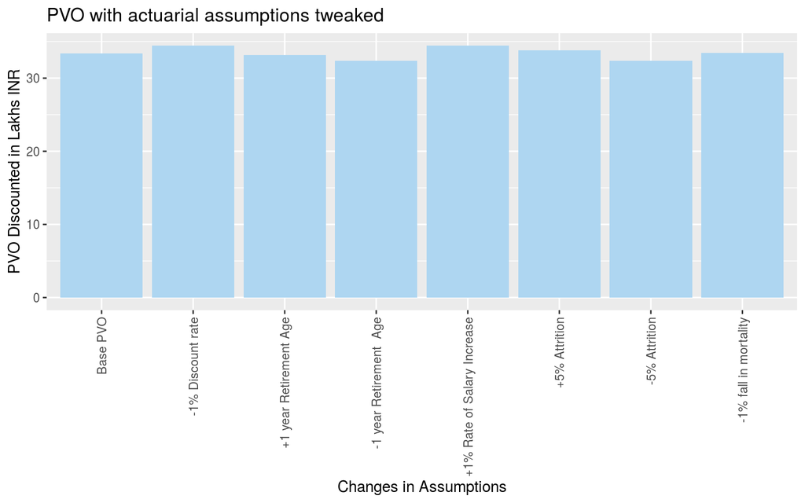

### 6.2 Distribution of PVO

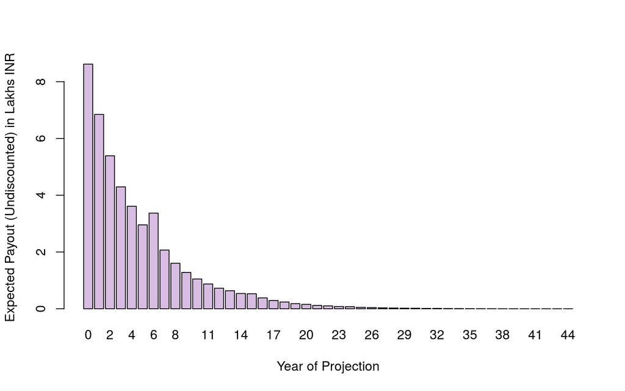

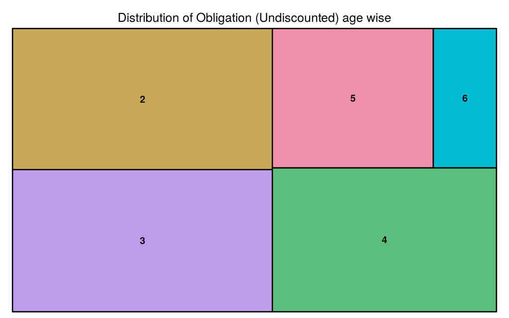

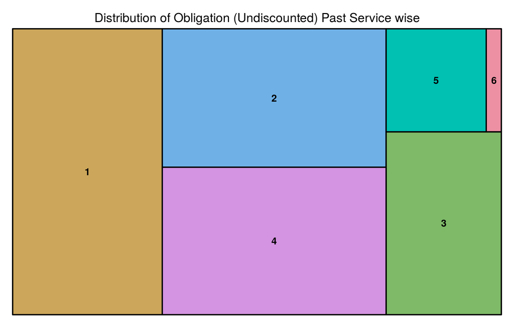

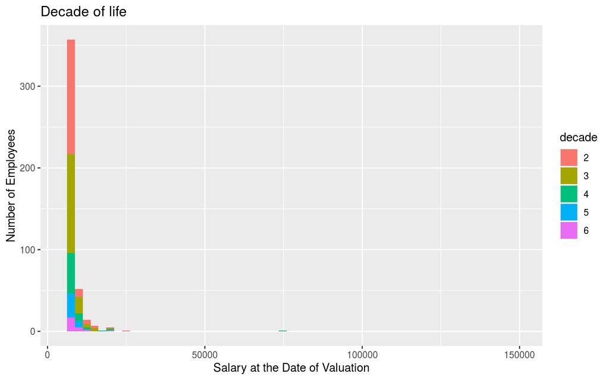